# Statistical Modelling II

Mauricio Garcia Tec

$$\DeclareMathOperator{\N}{N}
\DeclareMathOperator{\Gam}{Gamma}
\DeclareMathOperator{\Wish}{Wishart}
\DeclareMathOperator{\tr}{tr}
\DeclareMathOperator{\Po}{Poisson}$$

[Return to main Index](https://github.com/mauriciogtec/statsmodelling2)

# Section 3: Bayesian GLMs

## Modelling non-Gaussian observations

So far, we’ve assumed real-valued observations. In this setting, our likelihood model is a univariate normal, parametrized by a mean $x_i^T\beta$ and some precision that does not directly depend on the value of $x_i$. In general, $x_i^T\beta$ will take values in $\mathbb{R}$

If we don’t want to use a Gaussian likelihood, we typically won’t be able to parametrize our data using a real-valued parameter. Instead, we must transform it via an appropriate link function. This is, in essence, the generalized linear model.

As a first step into other types of data, let’s consider binary valued observations. Here, the natural likelihood model is a Bernoulli random variable; however we cannot directly parametrize this by $x_i^T\beta$. Instead, we must transform $x_i^T\beta$ to lie between $0$ and $1$ via some function $g^{-1}:\mathbb{R}\rightarrow (0,1)$. We can then write a linear model as

$$\begin{aligned}
y_i|p_i \sim& \mbox{Bernoulli}(p_i)\\
p_i =& g^{-1}(x_i^T\beta)\\
\beta|\theta \sim& \pi_\theta(\beta)
\end{aligned}$$

where $\pi_\theta(\beta)$ is our choice of prior on $\beta$. Unfortunately, there is no choice of prior here that makes the model conjugate.

Let’s start off with a normal prior on $\beta$. One appropriate function for $g^{-1}$ is the CDF of the normal distribution – known as the probit function. This is equivalent to assuming our data are generated according to

$$\begin{aligned}
y_i =& \begin{cases} 1 & if z>0 \\ 0 & \mbox{otherwise}\end{cases}\\
z_i \sim& \mbox{N}(x_i^T\beta, \tau^2)
\end{aligned}$$

If we put a normal-inverse gamma prior on $\beta$ and $\tau$, then we have a regression model on the $(x_i,z_i)$ pairs, that is idential to what we had before! Conditioned on the $z_i$, we can easily sample values for $\beta$ and $\tau$.

### Exercise 1

*Solution*. We are missing the conditional probability of the latent variable
$$(z_i \mid x_i,y_i,\beta, \tau) \sim \begin{cases}
N(x_i'\beta, \tau^2) \quad \text{truncated to } [0, \infty) \quad &\text{if }\quad y_i = 1 \\
N(x_i'\beta, \tau^2) \quad \text{truncated to } (-\infty, 0] \quad &\text{if }\quad y_i = 0
\end{cases}$$
The other conditionals are identical as in section two.

```r
library(tidyverse)
library(Matrix)
library(mvtnorm)
library(truncnorm)
```

```r
pima <- read_csv("./pima.csv")
head(pima)
```

| times_pregnant | plasma_glucose | dia_blood_pressure | triceps_skinfold | serum_insulin | bmi | pedigree | age | class_variable |
| --- | --- | --- | --- | --- | --- | --- | --- | --- |
| 6 | 148 | 72 | 35 | 0 | 33.6 | 0.627 | 50 | 1 |
| 1 | 85 | 66 | 29 | 0 | 26.6 | 0.351 | 31 | 0 |
| 8 | 183 | 64 | 0 | 0 | 23.3 | 0.672 | 32 | 1 |
| 1 | 89 | 66 | 23 | 94 | 28.1 | 0.167 | 21 | 0 |
| 0 | 137 | 40 | 35 | 168 | 43.1 | 2.288 | 33 | 1 |
| 5 | 116 | 74 | 0 | 0 | 25.6 | 0.201 | 30 | 0 |

```r
X <- pima %>%
  select(-class_variable) %>%
  mutate_each(funs(scale)) %>%
  add_column(`(Intercept)` = 1, .before = 1) %>%
  data.matrix()
y <- pima %>%
  pull(class_variable)
```

```r
gibbs_sampler1 <- function(nsim, X, y, prior) {
  n <- nrow(X)
  d <- ncol(X)

  # initialise
  beta <- matrix(0, nsim, d)
  omega <- numeric(nsim)
  z <- matrix(0, nsim + 1, n)

  # constant computed quantities
  an <- prior$a0 + n/2
  Kn_inv <- solve(crossprod(X, X) + prior$K0)
  lims <-  c(-Inf, 0, Inf) # nice trick to choose the truncation limits

  # sampler
  for (k in 1:nsim) {
    # random computed quantities
    mn <- Kn_inv %*% (crossprod(X, z[k, ]) + prior$K0 %*% prior$m0)
    bn <- prior$b0 + 0.5*drop(crossprod(z[k, ] - X %*% mn)) +
      0.5*drop(crossprod(mn - prior$m0, prior$K0 %*% (mn - prior$m0)))

    # sample
    omega[k] <- rgamma(1, shape = an, rate = bn)
    beta[k, ] <- rmvnorm(1, mean = mn, sigma = as(Kn_inv, "matrix") / omega[k])
    reg <- drop(X %*% beta[k, ])
    for (i in 1:n) {
      z[k + 1, i] <- rtruncnorm(1, lims[1 + y[i]], lims[2 + y[i]], reg[i], 1 / sqrt(omega[k]))
    }
  }
  z <- z[-1, ]

  list(beta = beta, tau = 1 / sqrt(omega), z = z)
}
```

```r
# Create prior
d <- ncol(X)
prior <- list(m0 = numeric(d), K0 = Diagonal(d), a0 = 1, b0 = 0.1, tau = 1)
# Run the sampler
nsim <- 10000
set.seed(999)
res1 <- gibbs_sampler1(nsim, X, y, prior)
```

```r
describe <- function(x) {
  data_frame(mean = mean(x), sd = sd(x), low95 = quantile(x, 0.025), up95 = quantile(x, 0.975))
}
beta <- res1$beta
beta %>%
  data.frame() %>%
  map(describe) %>%
  bind_rows() %>%
  add_column(variable = colnames(X), .before = 1)
```

| variable | mean | sd | low95 | up95 |
| --- | --- | --- | --- | --- |
| (Intercept) | -0.199569596 | 0.13964881 | -0.5913934621 | -0.063454392 |
| times_pregnant | 0.094192918 | 0.07080454 | 0.0241399243 | 0.297063688 |
| plasma_glucose | 0.245938365 | 0.16998050 | 0.0780782113 | 0.715343650 |
| dia_blood_pressure | -0.059849520 | 0.05016462 | -0.2108911307 | -0.007983633 |
| triceps_skinfold | 0.007447064 | 0.03152791 | -0.0513680359 | 0.085441292 |
| serum_insulin | -0.032819179 | 0.03617613 | -0.1384279402 | 0.011126502 |
| bmi | 0.160149147 | 0.11357829 | 0.0479976862 | 0.479513540 |
| pedigree | 0.062973040 | 0.04932001 | 0.0118019761 | 0.204971119 |
| age | 0.047218937 | 0.04429131 | -0.0006936722 | 0.176652208 |

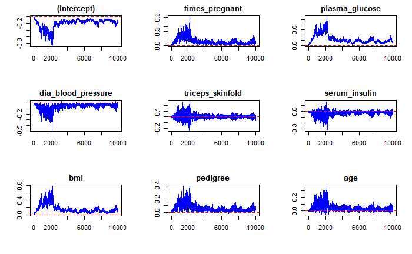

```r
par(mfrow = c(3, 3))
for (j in 1:ncol(beta)) {
  plot(beta[ , j],
       type = "l", col = "blue",
       main = colnames(X)[j],
       xlab = "",
       ylab = "")
  abline(h=0, col = "red", lt = 2)
}
```

This clearly doesn’t work super well. it took a long time for the chain to reach a stationary state; and it is very correlated. My explanation is that the variance should NOT be estimated! This is an identifiability problem. Instead I suggest to fix the variance at one.

In any case, let’s take a look at the predictions, they should work fine.

```r
burnin <- 100
pred <- X %*% t(beta) %>%
  apply(1, function(row) mean(as.integer(row > 0)))
table(obs = y, pred = round(pred))
```

```
   pred
obs   0   1
  0 446  54
  1 111 157
```

Accuracy

```r
sum(round(pred) == y) / length(y)
```

```
[1] 0.7851562
```

This is the accuracy we would get by simply predicting zero always

```r
sum(y == 0) / length(y)
```

```
[1] 0.6510417
```

Back to Index

### Exercise 2

*Sadly, the posterior isn’t in a “known” form. As a starting point, let’s find the maximum a posteriori estimator (MAP). The dataset “titantic.csv”" contains survival data from the Titanic; we’re going to look at probability of survival as a function of age. For now, we’re going to assume the intercept of our regression is zero – i.e. that $\beta$ is a scalar. Write a function (that can use a black-box optimizer! No need to reinvent the wheel. It shouldn’t be a long function) to estimate the MAP of $\beta$. Note that the MAP corresponds to the frequentist estimator using a ridge regularization penalty.*

*Solution*. This time instead of latent variables we’ll put a prior
$$\beta \sim N(\mu_0, \sigma_0^2)$$
and likelihood (we’ll treat the $x_i$ as fixed)
$$y_i | x_i, \beta \sim \mathrm{Binom}\left(m_i, w_i(\beta)\right)$$
where
$$w_i(\beta) = \frac{1}{1 + \exp\{-x_i'\beta\}}.$$
Then
$$\mathbb{P}(y_i = y \mid \beta) =w_i(\beta)^y(1 - w_i(\beta))^{1 - y}$$
The MAP (maximum a posteriori), is the max of the posterior.
$$p(\beta \mid y) \propto p(y \mid \beta)p(\beta)$$
Equivalently, we can minimize ($\simeq$ will mean equal up to a constant not depending on $\beta$)
$$\begin{aligned}
-\log(p(y \mid \beta)) - \log(p(\beta)) & \simeq -\sum_i \left(y_i\log(w_i(\beta)) + (1 - y_i)\log(1 - w_i(\beta))\right) + \frac{1}{2\sigma^2_0}(\beta - \mu)^2
\end{aligned}$$

Now let’s optimize it for the titanic data.

```r
library(tidyverse)
library(Matrix)
library(mvtnorm)
```

```r
titanic <- read_csv("./titanic.csv") %>%
  na.omit() %>%
  mutate(Survived = if_else(Survived == "Yes", 1, 0))
head(titanic)
```

| Name | PClass | Age | Sex | Survived |
| --- | --- | --- | --- | --- |
| Allen, Miss Elisabeth Walton | 1st | 29.00 | female | 1 |
| Allison, Miss Helen Loraine | 1st | 2.00 | female | 0 |
| Allison, Mr Hudson Joshua Creighton | 1st | 30.00 | male | 0 |
| Allison, Mrs Hudson JC (Bessie Waldo Daniels) | 1st | 25.00 | female | 0 |
| Allison, Master Hudson Trevor | 1st | 0.92 | male | 1 |
| Anderson, Mr Harry | 1st | 47.00 | male | 1 |

For this one dimensional problem we’ll predict survival using age only.

```r
X <- titanic %>%
  select(Age) %>%
  data.matrix()
y <- titanic %>%
  pull(Survived)
```

Define the function to evaluate the negative logposterior

```r
neg_lposterior <- function(beta, X, y, prior) {
  w = drop(1 / (1 + exp(-X %*% beta)))
  w = pmin(pmax(w, 1e-12), 1 - 1e-12)
  Sigma = as.matrix(Diagonal(ncol(X)) * prior$sigma0^2)
  -sum(y * log(w) + (1 - y) * log(1 - w)) - dmvnorm(beta, prior$mu0, Sigma, log = TRUE)
}
```

```r
prior <- list(mu0 = 0, sigma0 = 10)
test_beta <- seq(-2, 2, length.out = 1000)
post_values <- map_dbl(test_beta, ~neg_lposterior(., X, y, prior))
```

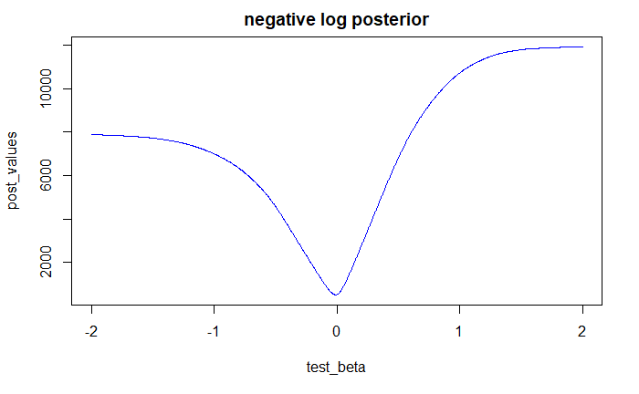

```r
plot(test_beta, post_values, type = "l", col = "blue", main = "negative log posterior")
```

Obtain the MAP

```r
optim_sol <- optimize(function(beta) neg_lposterior(beta, X, y, prior), lower = -1, upper = 1)
beta_map <- optim_sol$minimum
beta_map
```

```
[1] -0.01101179
```

Let’s verify this

```r
post_values <- map_dbl(test_beta, ~neg_lposterior(., X, y, prior))
plot(test_beta, post_values, type = "l", col = "blue", main = "negative log posterior")
abline(v = beta_map, col = "red", lt = 2)
```

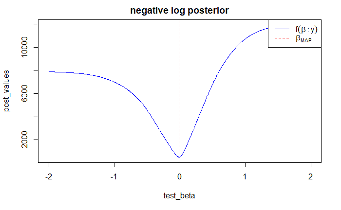

```r
legend("topright", c(expression(f(beta : y)), expression(beta[MAP])), col = c("blue", "red"), lt = c(1, 2))
```

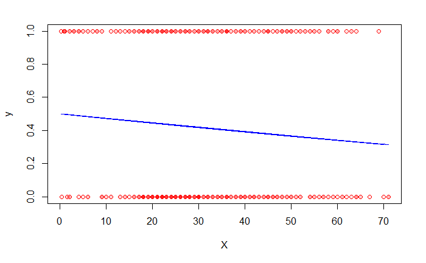

```r
plot(X, y, pch = 21, bg = alpha("red", 0.1), col = "red")
pred <- 1 / (1 + exp(-X * beta_map))
lines(X, pred, col = "blue")
```

We see his is not a very good model; it is important to note that we did not include an intercept at all.

Back to Index

### Exercise 3

*OK, we don’t know how to sample from the posterior, but we can at least look at it. Write a function to calculate the posterior pdf $p(\beta|\mathbf{x},\mathbf{y},\mu,\sigma^2)$, for some reasonable hyperparameter values $\mu$ and $\theta$ (up to a normalizing constant is fine!). Plot over a reasonable range of $\beta$ (your MAP from the last question should give you a hint of a reasonable range).*

*Solution*. This was already done in exercise 2 above.

The Laplace approximation is a method for approximating a distribution with a Gaussian, by matching the mean and variance at the mode. Let $P^*$ be the (unnormalized) PDF of a distribution we wish to approximate. We start by taking a Taylor expansion of the log (unnormalized) PDF at the global maximizing value $x^*$

$$\log P^*(x) \approx \log P^*(x^*) - \frac{c}{2}(x-x^*)^2$$

where $c = -\frac{\delta^2}{\delta x^2}\log P^*(x)\Big\rvert_{x=x^*}$.

We approximate $P^*$ with an unnormalized Gaussian, with the same mean and variance as $P^*$:
$$Q^*(x) = P^*(x^*)\exp\left\{-\frac{c}{2}(x-x^*)^2\right\}$$

Back to Index

### Exercise 4

Find the mean and precision of a Gaussian that can be used in a Laplace approximation to the posterior distribution over $\beta$.

*Solution*. The gradient and hessian of the prior term are trivial, we need only about computing the Hessian of the negative loglikelihood.

Thus, for the Laplace approximation we will use a Gaussian distribution with covariance matrix $(X'\Lambda X + I/\sigma_0^2)^{-1}$ centered at $\beta_\text{MAP}$. Let’s show it works

```r
test_beta <- seq(-.03, 0, length.out = 1000)
logposterior <- map_dbl(test_beta, ~ -neg_lposterior(., X, y, prior))
w_map <- drop(1 / (1 + exp(- X %*% beta_map)))
value_map <- -neg_lposterior(beta_map, X, y, prior)
Lambda <- Diagonal(x =  w_map * (1 - w_map))
hess <- drop(crossprod(X, Lambda %*% X) + Diagonal(ncol(X)) / prior$sigma0^2)
loglaplace <- map_dbl(test_beta, ~ value_map - 0.5*crossprod(. - beta_map, hess %*% (. - beta_map)))
```

```r
plot(test_beta, exp(loglaplace), type = "l", col = "red", main = "Laplace approximation")
lines(test_beta, exp(logposterior), col = "blue", lt = 3, lw = 2)
```

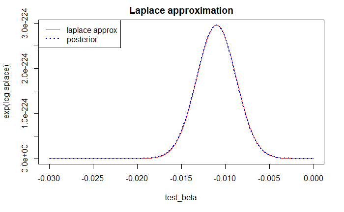

```r
legend("topleft", c("laplace approx", "posterior"), col = c("red", "blue"), lt = c(1, 3), lw = c(1, 2))
```

The above shows that the Laplace approximation is almost identical!

Back to Index

### Exercise 5

That’s all well and good… but we probably have a non-zero intercept. We can extend the Laplace approximation to multivariate PDFs. This amounts to estimating the precision matrix of the approximating Gaussian using the negative of the Hessian – the matrix of second derivatives
$$H_{ij} = \frac{\delta^2}{\delta x_i \delta x_j}\log P^*(x)\Big\rvert_{x=x^*}$$
Use this to approximate the posterior distribution over $\beta$. Give the form of the approximating distribution, plus 95% marginal credible intervals for its elements.

*Solution*. Luckily, we already developed the theory for themultivariate version in the previous exercise. I’ll just modify *X* and run the the optimizer again.

```r
X <- model.matrix(~ Age, data = titanic)
head(X)
```

```
  (Intercept)   Age
1           1 29.00
2           1  2.00
3           1 30.00
4           1 25.00
5           1  0.92
6           1 47.00
```

Solution

```r
prior <- list(mu0 = c(0, 1), sigma0 = 10)
optim_sol <- optim(c(0, 0), function(beta) neg_lposterior(beta, X, y, prior))
beta_map <- optim_sol$par
beta_map
```

```
[1] -0.081192090 -0.008800994
```

Now the Laplace approximation

```r
w_map <- drop(1 / (1 + exp(- X %*% beta_map)))
value_map <- -neg_lposterior(beta_map, X, y, prior)
Lambda <- Diagonal(x =  w_map * (1 - w_map))
hess <- drop(crossprod(X, Lambda %*% X) + Diagonal(ncol(X)) / prior$sigma0^2)
```

The covariance matrix is

```r
covmat = solve(hess)
covmat
```

```
2 x 2 Matrix of class "dgeMatrix"
              [,1]          [,2]
[1,]  0.0302187303 -8.228808e-04
[2,] -0.0008228808  2.736302e-05
```

From here we obtain the marginal distributions

```r
intercept_int <- qnorm(p = c(.025, .975), mean = beta_map[1], sd = sqrt(covmat[1, 1]))
age_int <- qnorm(p = c(.025, .975), mean = beta_map[2], sd = sqrt(covmat[2, 2]))
data_frame(
  variable = c('(Intercerpt)', 'Age'),
  mode = beta_map,
  sd = sqrt(diag(covmat)),
  'lower 95%' = c(intercept_int[1], age_int[1]),
  'upper 95%' = c(intercept_int[2], age_int[2]))
```

| variable | mode | sd | lower 95% | upper 95% |
| --- | --- | --- | --- | --- |
| (Intercerpt) | -0.081192090 | 0.173835354 | -0.4219031 | 0.259518943 |
| Age | -0.008800994 | 0.005230967 | -0.0190535 | 0.001451513 |

For comparison, we verify against R’s base glm function. We see that the results are extremely similar, including the standard deviation. Tiny differences are expected because of the approximation, but also the prior.

```r
mod <- glm(Survived ~ Age, family = binomial(), titanic)
summary(mod)
```

```
Call:
glm(formula = Survived ~ Age, family = binomial(), data = titanic)

Deviance Residuals:
    Min       1Q   Median       3Q      Max
-1.1418  -1.0489  -0.9792   1.3039   1.4801

Coefficients:
             Estimate Std. Error z value Pr(>|z|)
(Intercept) -0.081428   0.173862  -0.468   0.6395
Age         -0.008795   0.005232  -1.681   0.0928 .
---
Signif. codes:  0 ‘***’ 0.001 ‘**’ 0.01 ‘*’ 0.05 ‘.’ 0.1 ‘ ’ 1

(Dispersion parameter for binomial family taken to be 1)

    Null deviance: 1025.6  on 755  degrees of freedom
Residual deviance: 1022.7  on 754  degrees of freedom
AIC: 1026.7

Number of Fisher Scoring iterations: 4
```

Back to Index

We’re going to work with the dataset `tea_discipline_oss.csv`, a dataset gathered by Texas Appleseed, looking at the number of out of school suspensions (ACTIONS) accross schools in Texas. The data is censored for privacy reasons – data points with fewer than 5 actions are given the code ``-99’’. For now, we’re going to exclude these data points.

### Exercise 6

*We’re going to use a Poisson model on the counts. Ignoring the fact that the data is censored, why is this not quite the right model? Hint: there are several answers to this – the most fundamental involve considering the support of the Poisson.*

*Solution*

```r
library(tidyverse)
library(Matrix)
library(mvtnorm)
```

```r
discipline <- read_csv("./tea_discipline_oss.csv") %>%
  na.omit()
head(discipline)
```

| DISTNAME | CAMPNAME | GRADE | ETHNICX | SEXX | SE_ATTEND | ACTIONS | MIN_ACTIONS |
| --- | --- | --- | --- | --- | --- | --- | --- |
| CAYUGA ISD | CAYUGA H S | 10 | White | FEMALE | 0 | -99 | 1 |
| CAYUGA ISD | CAYUGA H S | 10 | White | FEMALE | 1 | -99 | 1 |
| CAYUGA ISD | CAYUGA H S | 11 | White | MALE | 1 | -99 | 1 |
| CAYUGA ISD | CAYUGA MIDDLE | 7 | White | MALE | 1 | -99 | 1 |
| CAYUGA ISD | CAYUGA MIDDLE | 8 | Hispanic/Latino | FEMALE | 1 | -99 | 1 |
| CAYUGA ISD | CAYUGA MIDDLE | 8 | White | FEMALE | 0 | -99 | 1 |

The following shows table shows the frequency of observations; -99 indicated the censored values.

```r
tbl <- table(discipline$ACTIONS)
df_tbl <- data_frame(value = names(tbl), count = as.integer(tbl))
df_tbl
```

| value | count |
| --- | --- |
| -99 | 53477 |
| 5 | 3445 |
| 6 | 2692 |
| 7 | 1944 |
| 8 | 1568 |
| 9 | 1288 |
| 10 | 1062 |
| 11 | 860 |
| 12 | 763 |
| 13 | 645 |

[output cut: 193 more lines]

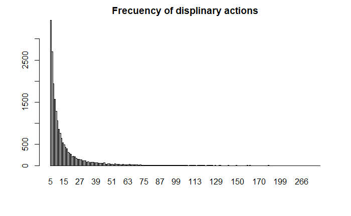

```r
barplot(df_tbl$count[-1], names = df_tbl$value[-1], main = "Frecuency of displinary actions")
```

If we observe a few things

- The value start at 5, which will be a problem for the Poission
- Even if it wasn’t censored, the Poisson always has positive probability of output zero, but this dataset contains data of people with positive actions only.
- If we see the graph, we observe that the distribution has very fat tails, so the Poisson wouldn’t also be a good fit in this sense.

Back to Index

### Exercise 7

*Let’s assume our only covariate of interest is GRADE and put a normal prior on $\beta$. Using a Laplace approximation and an appropriately vague prior, find 95% marginal credible intervals for the entries of $\beta$. You’ll probably want to use an intercept.*

*Solution*. The derivations of the derivatives is very similar. Define $w_i(\beta) = \exp\{x_i'\beta\}$, our likelihood this time is $y_i \sim \Po(w(\beta_i))$. Denote the negative loglikelihood as $l(\beta)$ as before, then
$$\begin{aligned}
\nabla_\beta l(\beta) &= \nabla_\beta \left\{ - \sum_{i = 1}^N(y_i\log(w_i(\beta)) - w_i(\beta)) \right\} \\
&= - \sum_{i = 1}^N \left\{ y_ix_i - w_i(\beta) x_i \right\} \\
&= - \sum_{i = 1}^N (y_i - w_i(\beta))x_i. \\
&= - X'(y - w). \\
\end{aligned}$$
Interestingly, we arrive to the same form of the gradient as in the binomial case. The Hessian of $l$ is
$$\nabla^2_\beta l(\beta) = -X'\nabla_\beta w(\beta) = -X'W X.$$
As before, we’ll use a prior $\beta \sim N(0, \sigma_0^2 I)$. So the Hessian of the negative logposterior is
$$-\nabla^2_\beta \log p(\beta \mid y) \bigg\vert_{\beta = \beta_*} = X' W X + \frac{1}{\sigma_0^2}I.$$

Now let’s do this with the data

```r
uncensored <- discipline %>%
  filter(ACTIONS != -99)
ethnicities <- unique(uncensored$ETHNICX)[-3] # remove white from the lsit
uncensored$ETHNICX <- factor(uncensored$ETHNICX, levels = c("White", ethnicities)) # make sure white is base group
uncensored$SEXX <- factor(uncensored$SEXX, levels = c("MALE", "FEMALE")) # male is base group
X <- uncensored %>%
  model.matrix(~ GRADE + ETHNICX + SEXX, data = .)
y <- uncensored %>%
  pull(ACTIONS)
```

Now the Laplace approximation

```r
neg_lposterior <- function(beta, X, y, prior) {
  w = exp(X %*% beta)
  w = pmax(w, 1e-24)
  Sigma = as.matrix(Diagonal(ncol(X)) * prior$sigma0^2)
  -sum(y * log(w) - w) - dmvnorm(beta, prior$mu0, Sigma, log = TRUE)
}
neg_lposterior_grad <- function(beta, X, y, prior) {
  w = exp(X %*% beta)
  drop(-crossprod(X, y - w)) - beta / prior$sigma0^2
}
```

```r
prior <- list(mu0 = numeric(ncol(X)), sigma0 = 10)
fn <- function(beta) neg_lposterior(beta, X, y, prior)
gr <- function(beta) neg_lposterior_grad(beta, X, y, prior)
optim_sol <- optim(numeric(ncol(X)), fn = fn, gr = gr)
beta_map <- setNames(optim_sol$par, nm = colnames(X))
beta_map
```

```
                         (Intercept)                                GRADE     ETHNICXBlack or African American
                           1.3984325                            0.0772508                            0.9775166
              ETHNICXHispanic/Latino             ETHNICXTwo or more races ETHNICXNative Hawaiian/Other Pacific
                           0.9663421                           -0.4031736                            0.8074929
                        ETHNICXAsian ETHNICXAmerican Indian or Alaska Nat                           SEXXFEMALE
                          -1.5800800                           -2.1001223                           -0.2698049
```

```r
w_map <- exp(X %*% beta_map)
value_map <- -neg_lposterior(beta_map, X, y, prior)
Lambda <- Diagonal(x = w_map)
hess <- drop(crossprod(X, Lambda %*% X) + Diagonal(ncol(X)) / prior$sigma0^2)
covmat <-  solve(hess)
```

From here we obtain the marginal distributions

```r
low <- map_dbl(1:ncol(X), ~qnorm(.025, mean = beta_map[.], sd = sqrt(covmat[., .])) )
upp <- map_dbl(1:ncol(X), ~qnorm(.975, mean = beta_map[.], sd = sqrt(covmat[., .])) )
data_frame(
  variable = colnames(X),
  mode = beta_map,
  sd = sqrt(diag(covmat)),
  'lower 95%' = low,
  'upper 95%' = upp)
```

| variable | mode | sd | lower 95% | upper 95% |
| --- | --- | --- | --- | --- |
| (Intercept) | 1.3984325 | 0.0082315478 | 1.38229896 | 1.41456604 |
| GRADE | 0.0772508 | 0.0006464307 | 0.07598382 | 0.07851778 |
| ETHNICXBlack or African American | 0.9775166 | 0.0069510613 | 0.96389273 | 0.99114039 |
| ETHNICXHispanic/Latino | 0.9663421 | 0.0067839407 | 0.95304585 | 0.97963841 |
| ETHNICXTwo or more races | -0.4031736 | 0.0269009935 | -0.45589854 | -0.35044859 |
| ETHNICXNative Hawaiian/Other Pacific | 0.8074929 | 0.0868832453 | 0.63720484 | 0.97778090 |
| ETHNICXAsian | -1.5800800 | 0.1006753342 | -1.77739998 | -1.38275992 |
| ETHNICXAmerican Indian or Alaska Nat | -2.1001223 | 0.1624791298 | -2.41857550 | -1.78166901 |
| SEXXFEMALE | -0.2698049 | 0.0040398523 | -0.27772288 | -0.26188695 |

And know a table of predictions vs observed (we anticipate big errors at the tale)

```r
tbl <- table(obs = y, pred = round(w_map))[1:10, 1:10]
tbl
```

```
    pred
obs    1   2   3   4   5   6   7   8   9  10
  5   25  12  29 129 123 218 126 188 146  92
  6   15  11  26  65  96 163  97 124 106  67
  7   10   7  12  40  45 105  70 102  87  48
  8    6   4   5  32  39  92  44  78  75  36
  9    6   3   2  15  27  53  33  73  57  16
  10   1   0   2  15  13  45  24  54  31  18
  11   5   0   2   7  11  32  24  32  30  15
  12   3   0   2   7   8  24  15  40  24  14
  13   0   1   0   7   6  19  18  27  19   9
  14   0   0   0   4   6  13  16  21  13   8
```

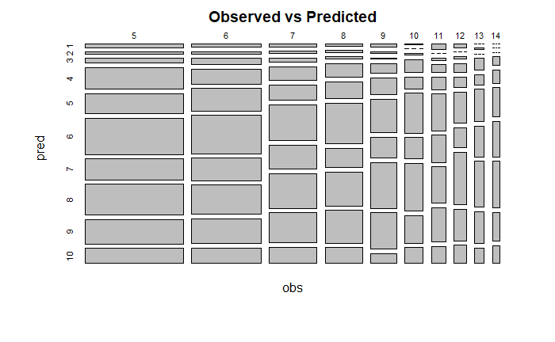

```r
plot(tbl, main = "Observed vs Predicted")
```

Total accuracy

```r
sum(round(w_map) == y) / length(y)
```

```
[1] 0.04067683
```

Accuracy up to one error

```r
sum(abs(round(w_map) - y) <= 1) / length(y)
```

```
[1] 0.1213613
```

Accuracy up to two error

```r
sum(abs(round(w_map) - y) <= 2) / length(y)
```

```
[1] 0.1887099
```

Back to Index

### Exercise 8

*I did this already in exercise 7.*

Back to Index

Even though we don’t have conjugacy, we can still use MCMC methods – we just can’t use our old friend the Gibbs sampler. Since this isn’t an MCMC course, let’s use STAN, a probabilistic programming language available for R, python and Matlab. I’m going to assume herein that we’re using RStan, and give appropriate scripts; it should be fairly straightforward to use if you’re an R novice, or if you want to use a different language, there are hints on translating to PyStan at `http://pystan.readthedocs.io/en/latest/differences\_pystan\_rstan.html` and info on MatlabStan (which seems much less popular) at `http://mc-stan.org/users/interfaces/matlab-stan`.

### Exercise 9

*Solution*. Here’s the stan model we are going to run. The model is saved as a variable `stanmodel9`.

```r
library(rstan)
```

```stan
// When run, this script generates the variable stanmodel9
// Basic Poisson glm
data {
  // Define variables in data
  // Number of observations (an integer)
  int<lower=0> N;
  // Covariates
  int <lower=0, upper=1> intercept[N];
  int <lower=-1, upper=12> x[N];
  // Count outcome
  int<lower=0> y[N];
}

parameters {
  // Define parameters to estimate
  real beta[2];
}

transformed parameters  {
  //
  real lp[N];
  real <lower=0> mu[N];

  for (i in 1:N) {
    // Linear predictor
    lp[i] = beta[1]*intercept[i] + beta[2]*x[i];
    // Mean
    mu[i] = exp(lp[i]);
  }
}

model {
  // Prior part of Bayesian inference
  beta[1]~normal(0,1);
  beta[2]~normal(0,1);
  // Likelihood part of Bayesian inference
  y ~ poisson(mu);
}
```

We now run it

```r
standata = list(N = nrow(X), intercept = X[, '(Intercept)'], x = X[ ,'GRADE'], y = y)
res9 <- sampling(stanmodel9,
  data = standata,
  chains = 2,
  iter = 1000,
  cores = 2,
  pars = "beta")
```

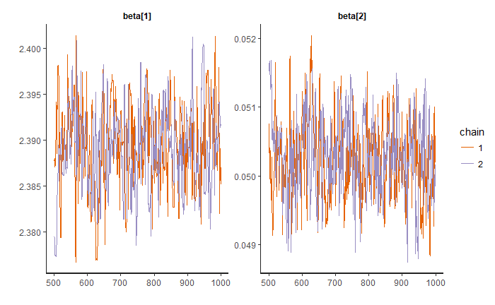

```r
traceplot(res9)
```

```r
describe <- function(x) {
  data_frame(mean = mean(x), sd = sd(x), low95 = quantile(x, 0.025), up95 = quantile(x, 0.975))
}
```

```r
beta <- rstan::extract(res9, "beta")[[1]]
beta <- data.frame(beta)
beta %>%
  map(describe) %>%
  bind_rows() %>%
  add_column(variable = c("(Intercept)", "GRADE"), .before = 1)
```

| variable | mean | sd | low95 | up95 |
| --- | --- | --- | --- | --- |
| (Intercept) | 2.38931144 | 0.0046286787 | 2.37943712 | 2.39776024 |
| GRADE | 0.05026472 | 0.0005703632 | 0.04918999 | 0.05147638 |

Back to Index

### Exercise 10

*Consider ways you might improve your regression (still, using the censored data) - while staying in the GLM framework. Ideas might include hierarchical error modeling (as we looked at in the last set of exercises), interaction terms… or something else! Looking at the data may give you inspiration. Implement this in STAN.*

We are going to do the following changes:

- Include multivariate regression
- Include a diffuse prior
- Negative binomial regression, with overdispersion parameter

```stan
// When run, this script generates the variable stanmodel9
// Basic Poisson glm
data {
  // Dimensions
  int <lower=0> N;
  int <lower=0> D;
  // Covariates and count outcome
  matrix[N, D] X;
  int <lower=0> y[N];
  // Prior hyperparams
  real mu0;
  real<lower=0> sigma0;
}

parameters {
  vector[D] beta; // logintensity
  real<lower=0> phi; // overdispersion
}

transformed parameters {
  vector[N] mu = X * beta; // logintensity
}

model {
  beta ~ normal(mu0, sigma0);
  y ~ neg_binomial_2_log(mu, phi);
}

generated quantities {
  vector[N] y_predict;
  for (i in 1:N)
    y_predict[i] = neg_binomial_2_log_rng(mu[i], phi);
}
```

We now run it

```r
standata = list(N = nrow(X), D = ncol(X), X = X, y = y, mu0 = 0, sigma0 = 10)
res10 <- sampling(stan10,
  data = standata,
  chains = 1,
  iter = 500,
  cores = 2)
```

```
Gradient evaluation took 0.016 seconds
1000 transitions using 10 leapfrog steps per transition would take 160 seconds.
Adjust your expectations accordingly!


Iteration:   1 / 500 [  0%]  (Warmup)
Iteration:  50 / 500 [ 10%]  (Warmup)
Iteration: 100 / 500 [ 20%]  (Warmup)
Iteration: 150 / 500 [ 30%]  (Warmup)
Iteration: 200 / 500 [ 40%]  (Warmup)
Iteration: 250 / 500 [ 50%]  (Warmup)
Iteration: 251 / 500 [ 50%]  (Sampling)
Iteration: 300 / 500 [ 60%]  (Sampling)
Iteration: 350 / 500 [ 70%]  (Sampling)
Iteration: 400 / 500 [ 80%]  (Sampling)
Iteration: 450 / 500 [ 90%]  (Sampling)
Iteration: 500 / 500 [100%]  (Sampling)

 Elapsed Time: 514.417 seconds (Warm-up)
               156.13 seconds (Sampling)
               670.547 seconds (Total)
```

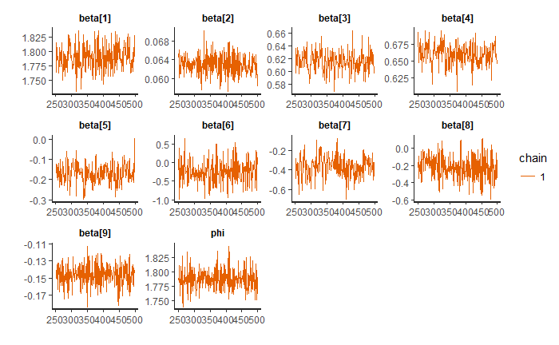

```r
traceplot(res10, pars = c("beta", "phi"))
```

Let’s compare the observation and mean predictions now

```r
yhat <- rstan::extract(res10, "y_predict")[[1]]
mu_mean <- apply(yhat, 2, mean)
mu_sd <- apply(yhat, 2, sd)
mu_mode_round <- apply(yhat, 2, function(r) {u <- unique(r); u[which.max(tabulate(match(r, u)))]})
pred_df <- data_frame(observed = y, "pred. mean" = mu_mean, "pred. sd" = mu_sd, "pred. round mode" = mu_mode_round)
pred_df
```

| observed | pred. mean | pred. sd | pred. round mode |
| --- | --- | --- | --- |
| 7 | 17.096 | 13.307560 | 5 |
| 11 | 20.688 | 15.649995 | 13 |
| 5 | 21.500 | 15.820085 | 7 |
| 8 | 14.104 | 11.411841 | 6 |
| 10 | 15.348 | 12.446306 | 7 |
| 25 | 16.160 | 12.734799 | 3 |
| 7 | 17.672 | 14.789976 | 7 |
| 9 | 18.784 | 14.298922 | 6 |
| 10 | 9.032 | 7.542049 | 2 |
| 9 | 13.412 | 10.331564 | 4 |

[output cut: 990 more lines]

```r
tbl = table(observed = y, predicted = mu_mode_round)[1:15, 1:15]
tbl
```

```
        predicted
observed   0   1   2   3   4   5   6   7   8   9  10  11  12  13  14
      5    2  88 229 337 371 373 384 334 285 230 195 157 114  75  74
      6    2  53 175 275 290 275 260 238 229 170 162 140  93  83  60
      7    4  46 114 196 203 188 212 165 178 153 114  77  58  60  37
      8    2  35  97 126 163 169 186 147 126 105  76  69  62  47  42
      9    0  24  66  97 129 128 146 115  98 109  87  73  52  44  35
      10   0  13  49  93  95  93 100  89  85 113  74  60  55  37  26
      11   0   7  41  70  68  85  85  72  81  67  55  46  48  31  31
      12   1   4  36  60  64  91  73  57  65  53  57  41  33  25  24
      13   0   5  20  43  58  65  77  67  49  63  41  33  32  22  16
      14   1   6  19  24  56  63  59  38  55  46  36  31  20  22  14
      15   0   2  16  22  46  46  36  49  52  34  42  36  27  22  19
      16   0   8  23  23  43  44  38  47  35  34  33  27  23  16   9
      17   0   5  10  25  27  43  54  41  32  30  27  30  24  13  12
      18   0   3   8  15  19  30  36  35  29  24  27  25  11  14   9
      19   0   5  17  15  17  23  31  22  28  31  22  12   8  18   8
```

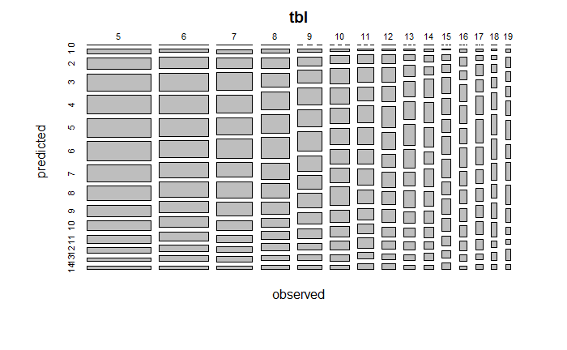

```r
plot(tbl)
```

```r
yhat2 <- as.integer(yhat)
hist(y[y < 40], breaks = 30, col = alpha("red", 0.2), prob = TRUE,
     main = "distribution observed vs posterior predictive mode", xlim = c(0, 40))
hist(yhat2[yhat2 < 40], breaks = 30, col = alpha("blue", 0.2), prob = TRUE, add = TRUE)
```

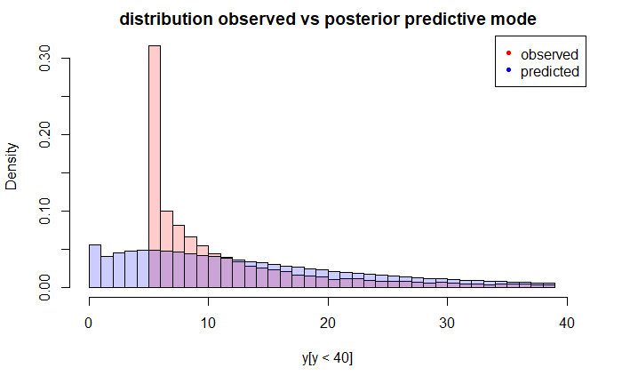

```r
legend("topright", c("observed", "predicted"), col = c("red", "blue"), pch = 20)
```

This model does a very good job in matching the shape. Unfortunately, it puts mass in zero where there should be none. Also it fails for small values.

Back to Index

### Exercise 11

*We are throwing away a lot of information by not using the censored data. Come up with a strategy, and write down how you would alter your model/sampler. Bonus points for actually implementing it in STAN (hint: look up the section on censored data in the STAN manual)*

*Solution*. In addition to the negative binomial model above, we will now include censored data.

```r
library(rstan)
library(tidyverse)
library(Matrix)
```

```r
discipline <- read_csv("./tea_discipline_oss.csv") %>%
  # slice(sample(nrow(.), 2500)) %>%
  na.omit()
```

```stan
data {
  // Dimensions
  int<lower=1> N_obs;
  int<lower=0> N_cens;
  int<lower=1> D;
  // Data
  matrix[N_obs, D] X_obs;
  matrix[N_cens, D] X_cens;
  int y_obs[N_obs];
  // Prior hyperparams
  real mu0;
  real<lower=0> sigma0;
}

parameters {
  vector[D] beta; // logintensity
  real<lower=0> phi; // overdispersion
}

transformed parameters  {
  vector[N_obs] mu_obs = X_obs * beta;
  vector[N_cens] mu_cens = X_cens * beta;
}

model {
  beta ~ normal(mu0, sigma0);
  y_obs ~ neg_binomial_2_log(mu_obs, phi);
  // (log) Likelihood for censored values
  for (n in 1:N_cens) {
    target += neg_binomial_2_log_lpmf(4 | mu_cens[n], phi);
  }
}

generated quantities {
  vector[N_obs] y_predict_obs;
  vector[N_cens] y_predict_cens;
  for (i in 1:N_obs)
    y_predict_obs[i] = neg_binomial_2_log_rng(mu_obs[i], phi);
  for (i in 1:N_cens)
    y_predict_cens[i] = neg_binomial_2_log_rng(mu_cens[i], phi);
}
```

```r
ethnicities <- unique(discipline$ETHNICX)[-1] # remove white from the lsit
discipline$ETHNICX <- factor(discipline$ETHNICX, levels = c("White", ethnicities)) # make sure white is base group
discipline$SEXX <- factor(discipline$SEXX, levels = c("MALE", "FEMALE")) # male is base group
X <- discipline %>%
  model.matrix(~ GRADE + ETHNICX + SEXX, data = .)
y <- discipline %>%
  pull(ACTIONS)
```

```r
X_obs <- X[y != -99, ]
X_cens <-  X[y == -99, ]
y_obs <-  y[y != -99]
stan_data <- list(
  N_obs = nrow(X_obs),
  N_cens = nrow(X_cens),
  D = ncol(X),
  X_obs = X_obs,
  X_cens = X_cens,
  y_obs = y_obs,
  mu0 = 0,
  sigma0 = 10
)
```

```r
res11 <- sampling(stan11,
  data = stan_data,
  chains = 1,
  pars = c("beta", "phi", "y_predict_obs", "y_predict_cens"),
  iter = 500)
```

```
Gradient evaluation took 0.06 seconds
1000 transitions using 10 leapfrog steps per transition would take 600 seconds.
Adjust your expectations accordingly!


Iteration:   1 / 500 [  0%]  (Warmup)
Iteration:  50 / 500 [ 10%]  (Warmup)
Iteration: 100 / 500 [ 20%]  (Warmup)
Iteration: 150 / 500 [ 30%]  (Warmup)
Iteration: 200 / 500 [ 40%]  (Warmup)
Iteration: 250 / 500 [ 50%]  (Warmup)
Iteration: 251 / 500 [ 50%]  (Sampling)
Iteration: 300 / 500 [ 60%]  (Sampling)
Iteration: 350 / 500 [ 70%]  (Sampling)
Iteration: 400 / 500 [ 80%]  (Sampling)
Iteration: 450 / 500 [ 90%]  (Sampling)
Iteration: 500 / 500 [100%]  (Sampling)

 Elapsed Time: 784.461 seconds (Warm-up)
               600.529 seconds (Sampling)
               1384.99 seconds (Total)
```

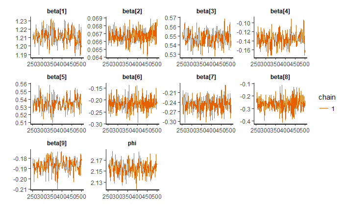

```r
traceplot(res11, pars = c("beta", "phi"))
```

Let’s compare the observation and mean predictions now

```r
yhat <- rstan::extract(res11, "y_predict_obs")[[1]]
yhat_cens <- rstan::extract(res11, "y_predict_cens")[[1]]
mu_mean <- apply(yhat, 2, mean)
mu_sd <- apply(yhat, 2, sd)
mu_mode_round <- apply(yhat, 2, function(r) {u <- unique(r); u[which.max(tabulate(match(r, u)))]})
pred_df <- data_frame(observed = y_obs, "pred. mean" = mu_mean, "pred. sd" = mu_sd, "pred. round mode" = mu_mode_round)
pred_df
```

| observed | pred. mean | pred. sd | pred. round mode |
| --- | --- | --- | --- |
| 7 | 8.532 | 7.397016 | 4 |
| 11 | 10.124 | 7.279601 | 7 |
| 5 | 11.380 | 8.342782 | 5 |
| 8 | 7.936 | 5.624450 | 2 |
| 10 | 7.712 | 5.667941 | 5 |
| 25 | 10.052 | 7.347465 | 4 |
| 7 | 9.380 | 6.849765 | 2 |
| 9 | 8.064 | 5.667131 | 4 |
| 10 | 5.324 | 3.696713 | 2 |
| 9 | 8.240 | 6.900207 | 4 |

[output cut: 990 more lines]

```r
tbl = table(observed = y_obs, predicted = mu_mode_round)[1:15, 1:14]
tbl
```

```
        predicted
observed   0   1   2   3   4   5   6   7   8   9  10  11  12  13
      5   10 260 642 660 652 462 334 180 106  66  41  18  11   0
      6    2 206 422 542 478 377 266 170  95  58  36  24   6   6
      7    5 121 319 372 355 257 221 128  76  37  27  14   9   1
      8    2  89 255 315 301 205 149 109  67  40  20  11   3   1
      9    2  66 175 250 249 185 144  93  49  30  29   8   4   4
      10   2  40 141 197 194 156 121  93  47  29  22  10   8   0
      11   1  37 107 162 164 135  87  68  42  26  14  10   2   4
      12   1  22  88 132 151 130 102  50  44  20  10   6   2   1
      13   0  23  75 121 119 118  70  53  30  16  11   8   0   0
      14   0  19  63  95  91  96  60  42  28  18  11   4   3   4
      15   1  19  46  89  98  85  61  49  21  12   2   8   2   0
      16   0  12  74  75  82  54  50  38  22  13   9   1   3   2
      17   0  12  51  72  77  59  50  26  25  13   6   5   3   0
      18   0  14  33  63  50  56  39  24  10  14   3   1   2   2
      19   0   9  28  58  47  52  39  35  15   5   5   1   0   2
```

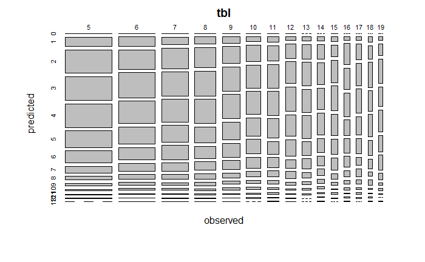

```r
plot(tbl)
```

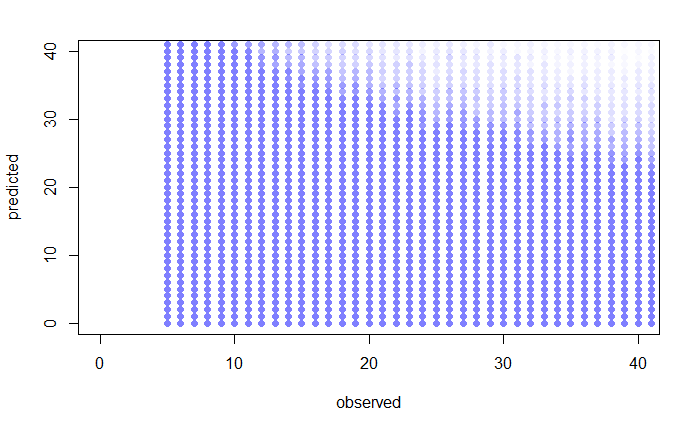

```r
pnts <- map(1:length(y_obs), ~data.frame(observed = y_obs[.x], predicted = yhat[ ,.x])) %>%
  bind_rows()
plot(pnts, xlim = c(0, 40), ylim = c(0, 40), pch = 16, col = alpha("blue", 0.005))
```

```r
yhat2 <- as.integer(yhat)
yhat3 <- as.integer(yhat_cens)
hist(y_obs[y_obs < 40], breaks = 30, col = alpha("red", 0.2), prob = TRUE,
     main = "distribution observed vs posterior predictive mode", xlim = c(0, 40))
hist(yhat2[yhat2 < 40], breaks = 30, col = alpha("blue", 0.2), prob = TRUE, add = TRUE)
```

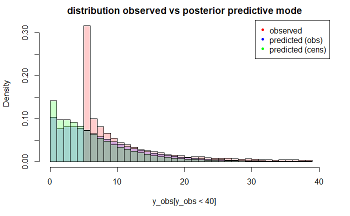

```r
hist(yhat3[yhat3 < 40], breaks = 30, col = alpha("green", 0.2), prob = TRUE, add = TRUE)
legend("topright", c("observed", "predicted (obs)", "predicted (cens)"), col = c("red", "blue", "green"), pch = 20)
```

This model does an even better job in capturing the shape thanks to including the censore data. The problem is mass at zero only, but we’ll do that in another day. One problem with this model is that while the prediction is accurate, the model is extremely dispersed.

Back to Index